# Between Sample (Beta) Diversity

Maya Craig

2024-04-30

# Goals

1. Load in phyloseq data with rooted tree.
2. Evaluate sequencing depth and remove sample.
3. Normalize the read counts between samples.
4. Calculate community dissimilarities. Numbers between 0 and 1. If 0, completely similar versus if they are 1, then they’re completely dissimilar.
   1. **Sorensen**: Shared Species as a binary value: Abundance-unweighted
   2. **Bray-Curtis**: Shared Abundant species: Abundance-weighted
   3. **(Abundance-)Weighted UNIFRAC**: Consider Abundant Species and where they fall on the tree
5. Visualize the community data with two unconstrained Ordinations:
   1. **PCoA**: Linear Method. Eigenvalue = how much variation is explained by each axis. Choose to view axis 1, 2, 3, etc. and plot them together.
   2. **NMDS**: Non-linear. Smush multiple Dimensions into 2 or 3 axes. Need to report Stress value (ideally <0.15).
6. Run statistics with PERMANOVA and betadispR.

# Setup

## Set the seed

```r
set.seed(98572)
```

## Load Libraries

```r
#install.packages("vegan")
pacman::p_load(tidyverse, devtools, phyloseq, patchwork, vegan,
               install = FALSE)

# set colors
all_samples_colors <- c(
  "p-diarrhea" = "deeppink",
  "p-control" = "royalblue1",
  "l-control" = "goldenrod1",
  "l-diarrhea" = "springgreen")

poodle_colors <- c("p-diarrhea" = "deeppink",
                  "p-control" = "springgreen")

laborador_colors <- c("l-diarrhea" = "deeppink",
                  "l-control" = "springgreen")

health_colors <- c("p-control" = "deeppink",
                   "l-control" = "springgreen")
```

## Load Data

```r
# Load in rooted phylogenetic tree!
load("data/03_Phylogenetic_Tree/phytree_preprocessed_physeq.RData")
unrooted_physeq_rmASVs
```

```
## phyloseq-class experiment-level object
## otu_table()   OTU Table:         [ 4892 taxa and 41 samples ]
## sample_data() Sample Data:       [ 41 samples by 50 sample variables ]
## tax_table()   Taxonomy Table:    [ 4892 taxa by 9 taxonomic ranks ]
## phy_tree()    Phylogenetic Tree: [ 4892 tips and 4890 internal nodes ]
```

# Explore Read Counts

## Raw read depth

```r
# Calculate the total number of reads per sample.
raw_TotalSeqs_df  <-
  midroot_physeq_rmASVs %>%
  # calculate the sample read sums
  sample_sums() %>%
  data.frame()
# name the column
colnames(raw_TotalSeqs_df)[1] <- "TotalSeqs"

head(raw_TotalSeqs_df)
```

```
##             TotalSeqs
## SRR23008984     71252
## SRR23008985     61050
## SRR23008986     63098
## SRR23008987     68157
## SRR23008988     62121
## SRR23008989     53198
```

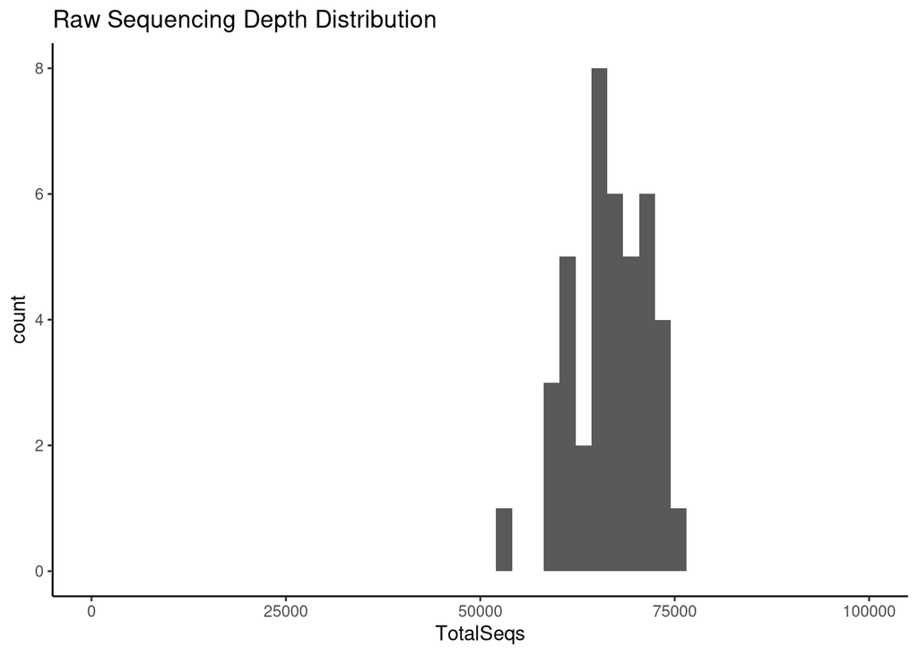

```r
# make histogram of raw reads
raw_TotalSeqs_df %>%
  ggplot(aes(x = TotalSeqs)) +
  geom_histogram(bins = 50) +
  scale_x_continuous(limits = c(0, 100000)) +
  labs(title = "Raw Sequencing Depth Distribution") +
  theme_classic()
```

## Normalize read counts

```r
### scale_reads function
####################################################################################
# Function to scale reads: http://deneflab.github.io/MicrobeMiseq/
# Scales reads by
# 1) taking proportions
# 2) multiplying by a given library size of n
# 3) rounding
# Default for n is the minimum sample size in your library
# Default for round is floor

matround <- function(x){trunc(x+0.5)}

scale_reads <- function(physeq, n = min(sample_sums(physeq)), round = "round") {

  # transform counts to n
  physeq.scale <- transform_sample_counts(physeq, function(x) {(n * x/sum(x))})

  # Pick the rounding functions
  if (round == "floor"){
    otu_table(physeq.scale) <- floor(otu_table(physeq.scale))
  } else if (round == "round"){
    otu_table(physeq.scale) <- round(otu_table(physeq.scale))
  } else if (round == "matround"){
    otu_table(physeq.scale) <- matround(otu_table(physeq.scale))
  }

  # Prune taxa and return new phyloseq object
  physeq.scale <- prune_taxa(taxa_sums(physeq.scale) > 0, physeq.scale)
  return(physeq.scale)
}
```

## Scale the reads and check the distribution of the seq depth

```r
min(sample_sums(midroot_physeq_rmASVs))
```

```
## [1] 53198
```

```r
# Scale reads by the above function
scaled_rooted_physeq <-
  midroot_physeq_rmASVs %>%
  scale_reads(round = "matround")

# Calculate the read depth
scaled_TotalSeqs_df <-
  scaled_rooted_physeq %>%
  sample_sums() %>%
  data.frame()
colnames(scaled_TotalSeqs_df)[1] <-"TotalSeqs"

# Inspect
head(scaled_TotalSeqs_df)
```

```
##             TotalSeqs
## SRR23008984     53175
## SRR23008985     53209
## SRR23008986     53210
## SRR23008987     53199
## SRR23008988     53208
## SRR23008989     53198
```

```r
# Check the range of the data
min_seqs <- min(scaled_TotalSeqs_df$TotalSeqs); min_seqs
```

```
## [1] 53159
```

```r
max_seqs <- max(scaled_TotalSeqs_df$TotalSeqs); max_seqs
```

```
## [1] 53225
```

```r
# range
max_seqs - min_seqs
```

```
## [1] 66
```

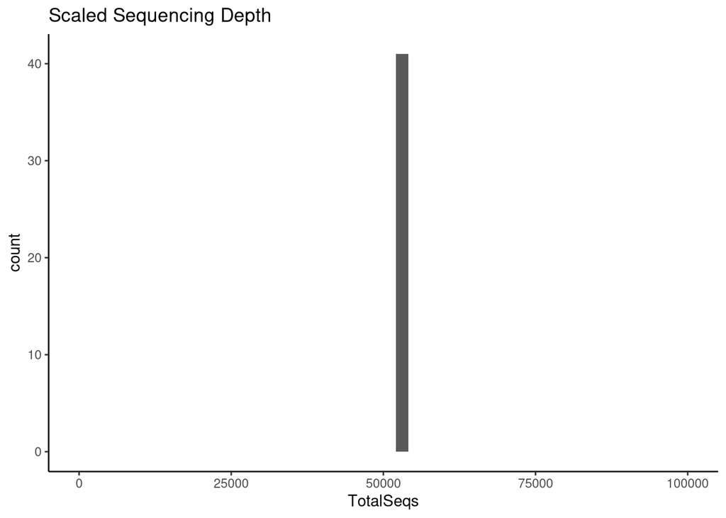

```r
# Plot Histogram
scaled_TotalSeqs_df %>%
  ggplot(aes(x = TotalSeqs)) +
  geom_histogram(bins = 50) +
  scale_x_continuous(limits = c(0, 100000)) +
  labs(title = "Scaled Sequencing Depth") +
  theme_classic()
```

```r
#subset physeq obj by each breed for later ordination plots
poodle_physeq <- subset_samples(scaled_rooted_physeq, breed == "poodle")
laborador_physeq <-subset_samples(scaled_rooted_physeq, breed == "laborador")
health_physeq <- subset_samples(scaled_rooted_physeq, health == "healthy")
```

# Cacluate & Visualize community dissimilarity

## PCoA

### Sorensen

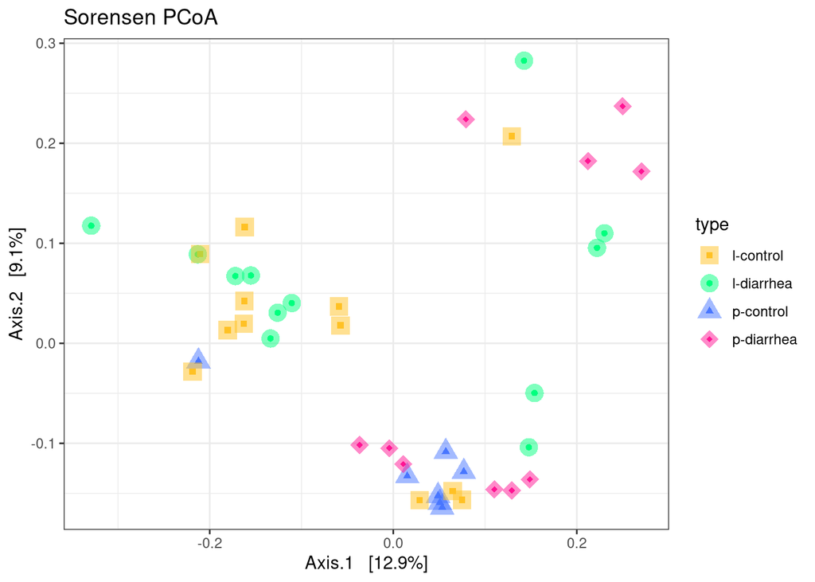

```r
# Calculate sorensen dissimilarity: Abundance-unweighted of shared taxa
scaled_soren_pcoa <-
  ordinate(
    physeq = scaled_rooted_physeq,
    method = "PCoA",
    distance = "bray", binary = TRUE)

health_scaled_soren_pcoa <-
  ordinate(
    physeq = health_physeq,
    method = "PCoA",
    distance = "bray", binary = TRUE)

#str(scaled_soren_pcoa)

# Plot the ordination for all samples
soren_all_pcoa <- plot_ordination(
  physeq = scaled_rooted_physeq,
  ordination = scaled_soren_pcoa,
  color = "type",
  shape = "type",
  title = "Sorensen PCoA") +
  geom_point(size=5, alpha = 0.5, aes(color = type)) +
  scale_shape_manual(values = c(15,16,17,18, 19, 20)) +
  scale_color_manual(values = all_samples_colors) +
  theme_bw()
# Show the plot
soren_all_pcoa
```

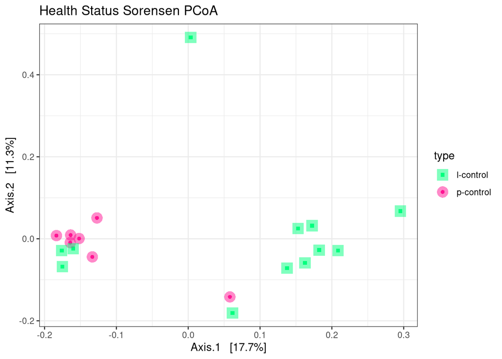

```r
# straify by health status
soren_health_pcoa <- plot_ordination(
  physeq = health_physeq,
  ordination = health_scaled_soren_pcoa,
  color = "type",
  shape = "type",
  title = "Health Status Sorensen PCoA") +
  geom_point(size=5, alpha = 0.5, aes(color = type)) +
  scale_shape_manual(values = c(15,16,17,18, 19, 20)) +
  scale_color_manual(values = health_colors) +
  theme_bw()
# Show the plot
soren_health_pcoa
```

**Interpretation**: For the Sorensen PCoA plot, 12.9% of variation is explained by Axis 1 and 9.1% of variation is explained by Axis 2. In total, 22% of variation is explained by the Sorensen statistic. There is not any clear clustering of certain characteristics. The Sorensen metric is unweighted and uses a binary variable to indicate the presence and absence of a taxa. This is consistent with findings from Bai et al, 2023.

For the sorensen plot that displays the ordinance of health status, axis 1 explains 17.7% of variation and axis 2 explains 11.3% of the variation. In total, the Sorensen metric explains 29% of variation between the two breeds of healthy dogs. There seems to be more of a clear separation between healthy Labradors and healthy poodles. This is consistent with the findings of Bai et al, 2023

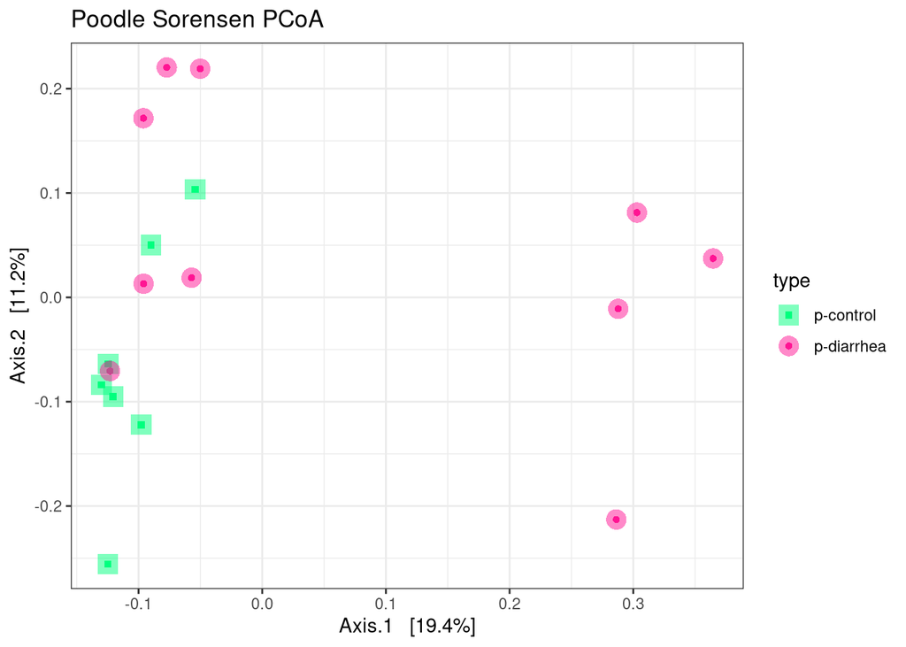

```r
poodle_scaled_soren_pcoa <-
  ordinate(
    physeq = poodle_physeq,
    method = "PCoA",
    distance = "bray", binary = TRUE)

laborador_scaled_soren_pcoa <-
  ordinate(
    physeq = laborador_physeq,
    method = "PCoA",
    distance = "bray", binary = TRUE)

# Poodle sorensen plots
soren_poodle_pcoa <- plot_ordination(
  physeq = poodle_physeq,
  ordination = poodle_scaled_soren_pcoa,
  color = "type",
  shape = "type",
  title = "Poodle Sorensen PCoA") +
  geom_point(size=5, alpha = 0.5, aes(color = type)) +
  scale_shape_manual(values = c(15,16,17,18, 19, 20)) +
  scale_color_manual(values = poodle_colors) +
  theme_bw()
# Show the plot
soren_poodle_pcoa
```

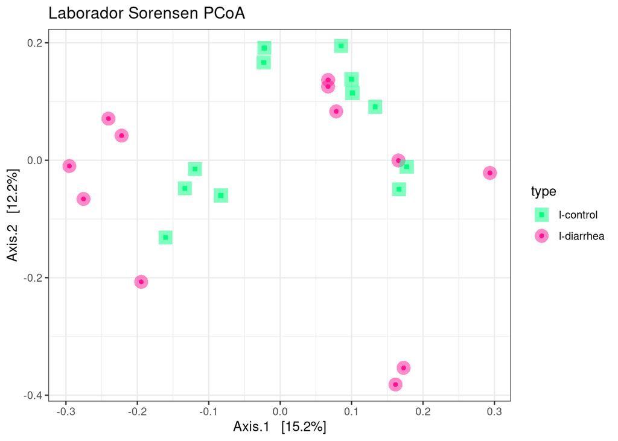

```r
# Labrador sorensen plots
soren_laborador_pcoa <- plot_ordination(
  physeq = laborador_physeq,
  ordination = laborador_scaled_soren_pcoa,
  color = "type",
  shape = "type",
  title = "Laborador Sorensen PCoA") +
  geom_point(size=5, alpha = 0.5, aes(color = type)) +
  scale_shape_manual(values = c(15,16,17,18, 19, 20)) +
  scale_color_manual(values = laborador_colors) +
  theme_bw()
# Show the plot
soren_laborador_pcoa
```

For the Sorensen PCoA that compares the control and diarrhea samples from poodles, Axis 1 explains 19.4% of the variation, and axis 2 explains 11.2% of the variation. In total. 30.6% of variation is explained by the Sorensen metric for samples from Poodles. There seems to be somewhat separation between the control and diarrhea samples. This is consistent with the findings from Bai et al, 2023.

### Bray

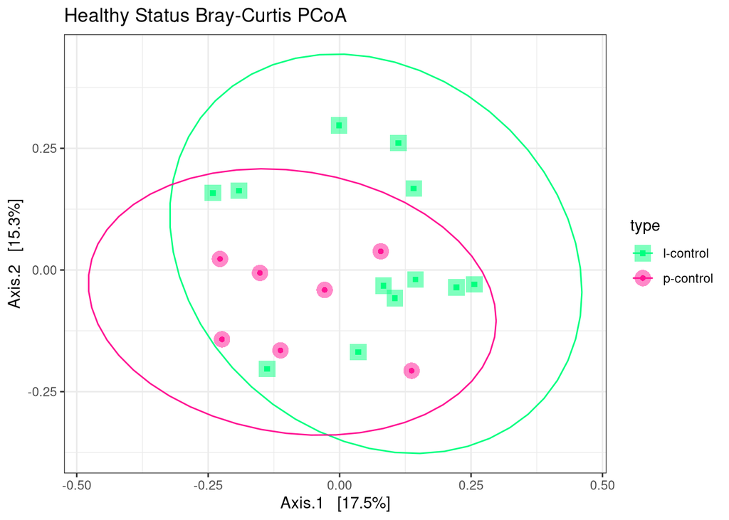

```r
# Calculate the BC distance
scaled_BC_pcoa <-
  ordinate(
    physeq = scaled_rooted_physeq,
    method = "PCoA",
    distance = "bray")

health_scaled_BC_pcoa <-
  ordinate(
    physeq = health_physeq,
    method = "PCoA",
    distance = "bray")

poodle_scaled_BC_pcoa <-
  ordinate(
    physeq = poodle_physeq,
    method = "PCoA",
    distance = "bray")

laborador_scaled_BC_pcoa <-
  ordinate(
    physeq = laborador_physeq,
    method = "PCoA",
    distance = "bray")

# Plot the PCoA
bray_health_pcoa <- plot_ordination(
  physeq = health_physeq,
  ordination = health_scaled_BC_pcoa,
  color = "type",
  shape = "type",
  title = "Healthy Status Bray-Curtis PCoA") +
  geom_point(size=5, alpha = 0.5, aes(color = type)) +
  scale_shape_manual(values = c(15,16,17,18, 19, 20)) +
  scale_color_manual(values = health_colors) +
  theme_bw() + stat_ellipse()
# Show the plot
bray_health_pcoa
```

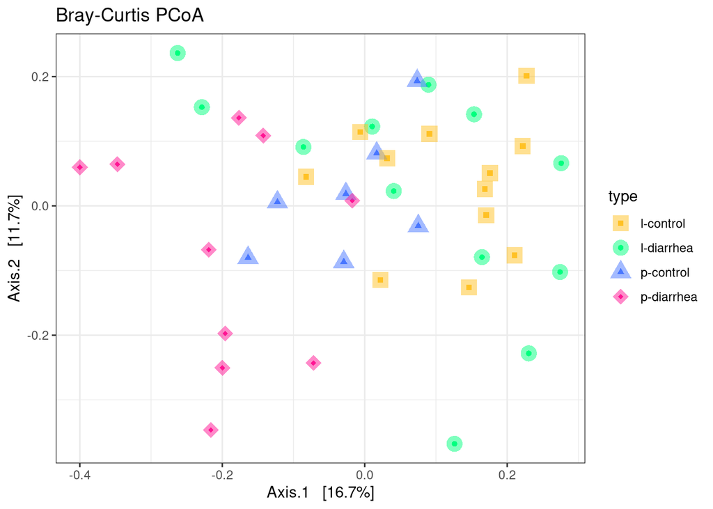

```r
bray_all_pcoa <-
  plot_ordination(
    physeq = scaled_rooted_physeq,
    ordination = scaled_BC_pcoa,
    color = "type",
    shape = "type",
    title = "Bray-Curtis PCoA") +
  geom_point(size=5, alpha = 0.5, aes(color = type)) +
  scale_shape_manual(values = c(15,16,17,18, 19, 20)) +
  scale_color_manual(values = c(all_samples_colors)) +
  theme_bw()
bray_all_pcoa
```

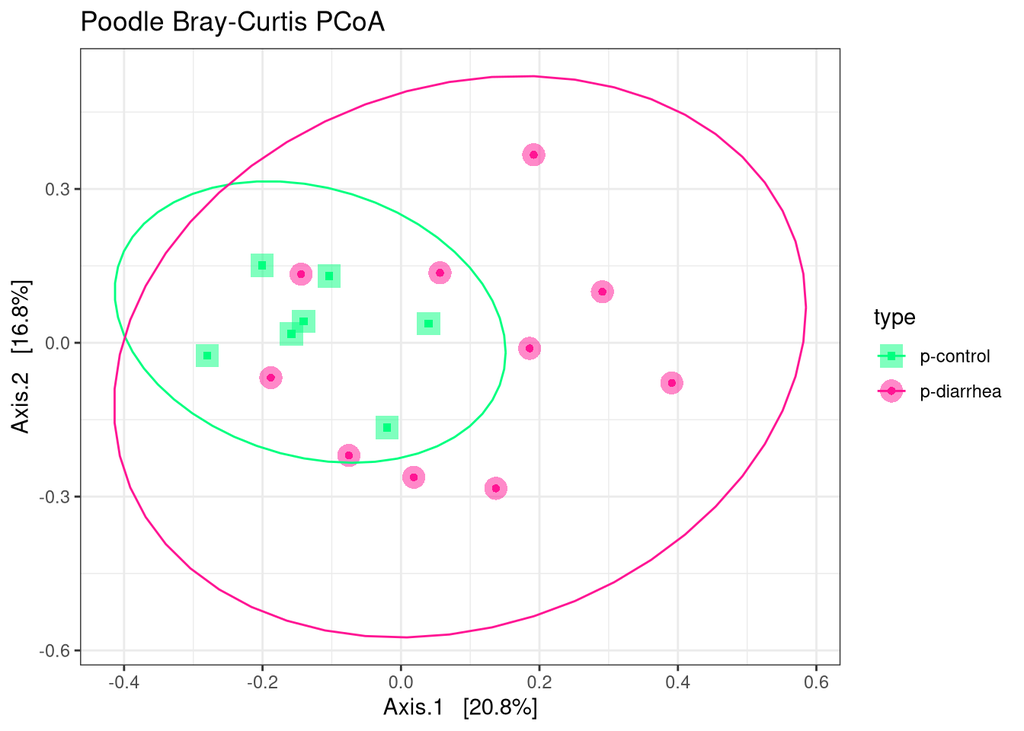

```r
# Poodle BC plots
bray_poodle_pcoa <- plot_ordination(
  physeq = poodle_physeq,
  ordination = poodle_scaled_BC_pcoa,
  color = "type",
  shape = "type",
  title = "Poodle Bray-Curtis PCoA") +
  geom_point(size=5, alpha = 0.5, aes(color = type)) +
  scale_shape_manual(values = c(15,16,17,18, 19, 20)) +
  scale_color_manual(values = poodle_colors) +
  theme_bw() + stat_ellipse()
# Show the plot
bray_poodle_pcoa
```

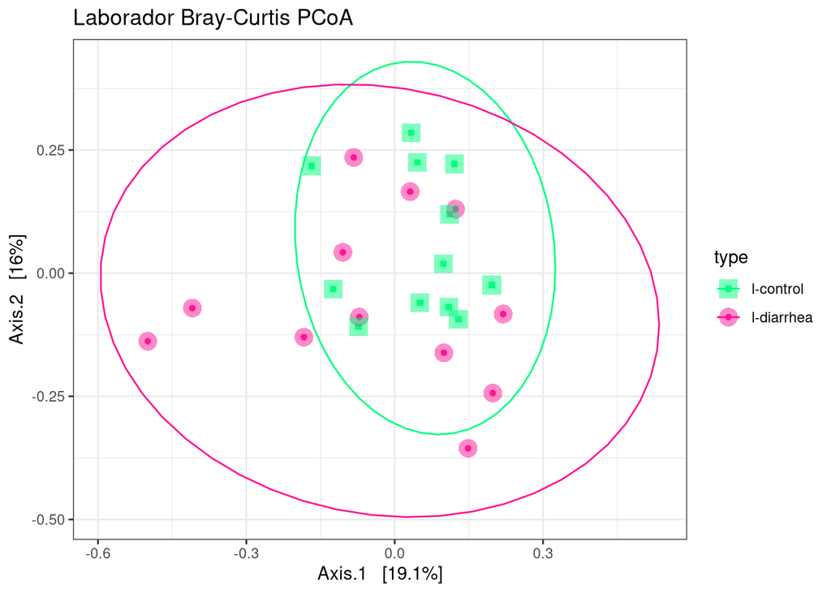

```r
# Laborador BC plots
bray_laborador_pcoa <- plot_ordination(
  physeq = laborador_physeq,
  ordination = laborador_scaled_BC_pcoa,
  color = "type",
  shape = "type",
  title = "Laborador Bray-Curtis PCoA") +
  geom_point(size=5, alpha = 0.5, aes(color = type)) +
  scale_shape_manual(values = c(15,16,17,18, 19, 20)) +
  scale_color_manual(values = laborador_colors) +
  theme_bw() + stat_ellipse()
# Show the plot
bray_laborador_pcoa
```

**Interpretations:** The Bray-Curtis metric evaluates beta-diversity by weighted shared taxa by their abundance. For the plot comparing diversity between samples from healthy breeds, we see that Axis 1 explains 17.5% of variation, and Axis 2 explains 15.3% variation. Therefore, 32.8% variation is explained by this plot. There is some separation by breed.

For the plot comparing diversity between all samples, we see that Axis 1 explains 16.7% of variation, and Axis 2 explains 11.7% variation. Therefore, 28.4% variation is explained by this plot. There is clustering by sample type.

For the plot comparing diversity between poodle samples, we see that Axis 1 explains 20.8% of variation, and Axis 2 explains 16.8% variation. Therefore, 37.6% variation is explained by this plot. There is clustering by sample type.

### Weighted Unifrac

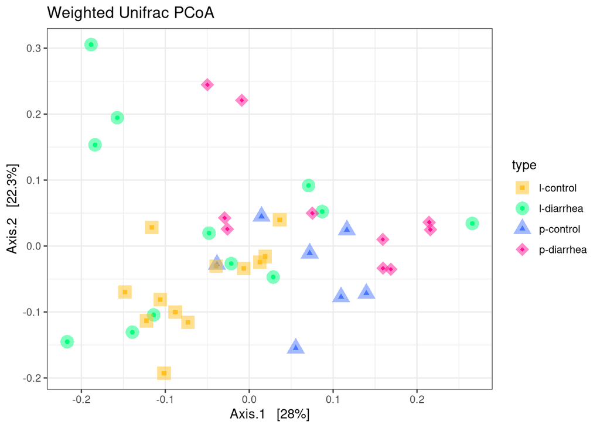

```r
# Calculate the BC distance
scaled_wUNI_pcoa <-
  ordinate(
    physeq = scaled_rooted_physeq,
    method = "PCoA",
    distance = "wunifrac")

health_scaled_wUNI_pcoa <-
  ordinate(
    physeq = health_physeq,
    method = "PCoA",
    distance = "wunifrac")

poodle_scaled_wUNI_pcoa <-
  ordinate(
    physeq = poodle_physeq,
    method = "PCoA",
    distance = "wunifrac")

laborador_scaled_wUNI_pcoa <-
  ordinate(
    physeq = laborador_physeq,
    method = "PCoA",
    distance = "wunifrac")

# Plot the PCoA
wUNI_all_pcoa <-
  plot_ordination(
    physeq = scaled_rooted_physeq,
    ordination = scaled_wUNI_pcoa,
    color = "type",
    shape = "type",
    title = "Weighted Unifrac PCoA") +
  geom_point(size=5, alpha = 0.5, aes(color = type)) +
  scale_shape_manual(values = c(15,16,17,18, 19, 20)) +
  scale_color_manual(values = c(all_samples_colors)) +
  theme_bw()
wUNI_all_pcoa
```

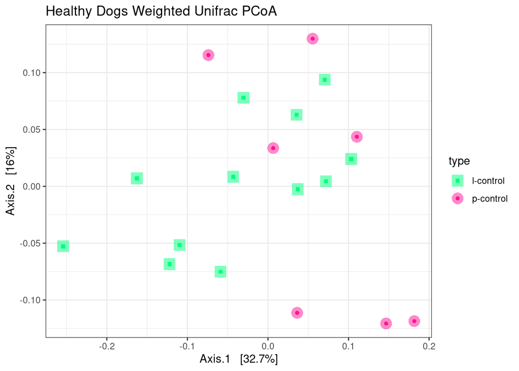

```r
wUNI_health_pcoa <- plot_ordination(
  physeq = health_physeq,
  ordination = health_scaled_wUNI_pcoa,
  color = "type",
  shape = "type",
  title = "Healthy Dogs Weighted Unifrac PCoA") +
  geom_point(size=5, alpha = 0.5, aes(color = type)) +
  scale_shape_manual(values = c(15,16,17,18, 19, 20)) +
  scale_color_manual(values = health_colors) +
  theme_bw()
# Show the plot
wUNI_health_pcoa
```

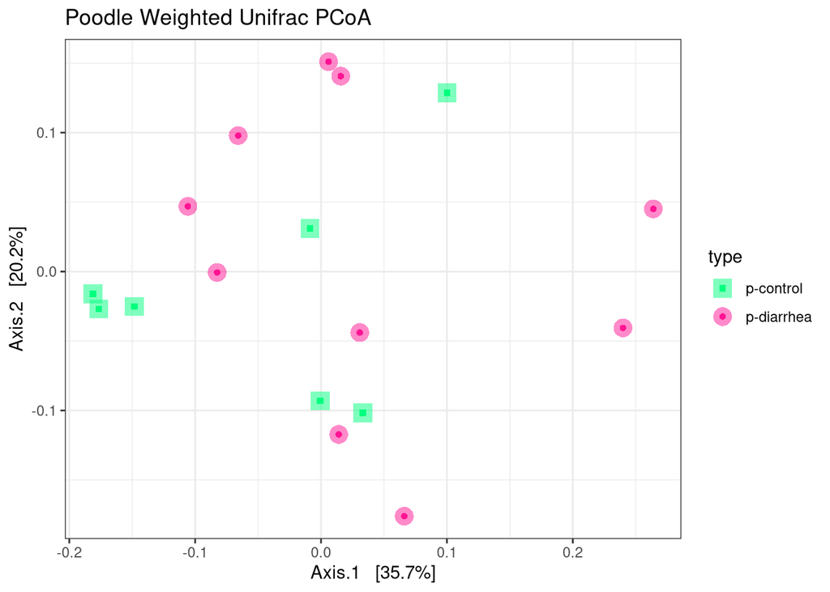

```r
wUNI_poodle_pcoa <-
  plot_ordination(
    physeq = poodle_physeq,
    ordination = poodle_scaled_wUNI_pcoa,
    color = "type",
    shape = "type",
    title = "Poodle Weighted Unifrac PCoA") +
  geom_point(size=5, alpha = 0.5, aes(color = type)) +
  scale_shape_manual(values = c(15,16,17,18, 19, 20)) +
  scale_color_manual(values = c(poodle_colors)) +
  theme_bw()
wUNI_poodle_pcoa
```

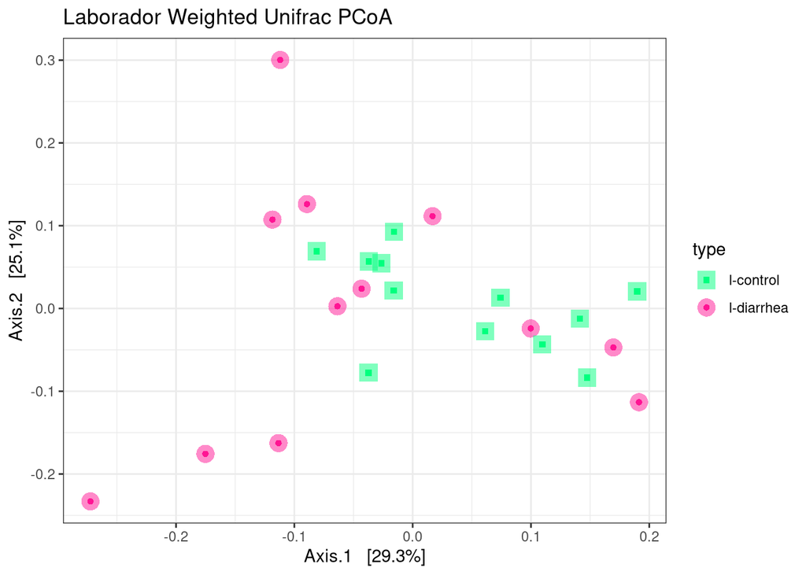

```r
wUNI_laborador_pcoa <-
  plot_ordination(
    physeq = laborador_physeq,
    ordination = laborador_scaled_wUNI_pcoa,
    color = "type",
    shape = "type",
    title = "Laborador Weighted Unifrac PCoA") +
  geom_point(size=5, alpha = 0.5, aes(color = type)) +
  scale_shape_manual(values = c(15,16,17,18, 19, 20)) +
  scale_color_manual(values = c(laborador_colors)) +
  theme_bw()
wUNI_laborador_pcoa
```

In plot comparing beta diversity between all samples, Axis 1 explains 28% of variation, and Axis 2 explains 22.3% of variation. In total, 50.3% of variation is explained in this plot. This is the highest amount of variation that is explained thus far.There seems more separation due to sample and breed type.

In plot comparing beta diversity between all control samples, Axis 1 explains 32.7% of variation, and Axis 2 explains 16% of variation. In total, 48.7% of variation is explained in this plot. There seems to be clustering by sample type.

In plot comparing beta diversity between all poodle samples, Axis 1 explains 35.7% of variation, and Axis 2 explains 20.2% of variation. In total, 55.9% of variation is explained in this plot. This is the highest amount of variation that is explained thus far.

In plot comparing beta diversity between all laborador samples, Axis 1 explains 29.3% of variation, and Axis 2 explains 25.1% of variation. In total, 54.4% of variation is explained in this plot.There seems to be clustering by sample type.

## Combine PCoAs

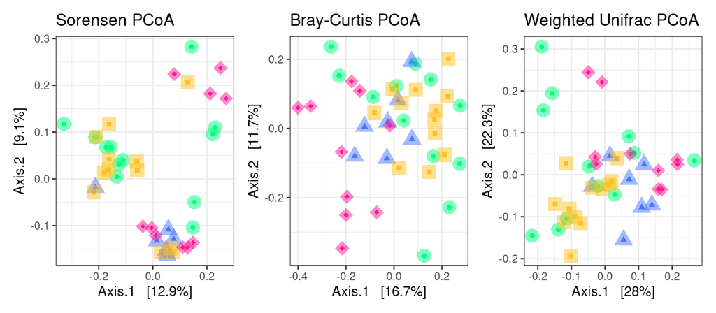

```r
(soren_all_pcoa + theme(legend.position = "none")) +
  (bray_all_pcoa + theme(legend.position = "none")) +
    (wUNI_all_pcoa + theme(legend.position = "none"))
```

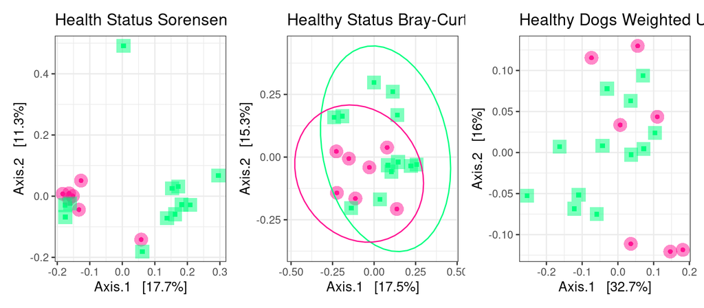

```r
(soren_health_pcoa + theme(legend.position = "none")) +
  (bray_health_pcoa + theme(legend.position = "none")) +
    (wUNI_health_pcoa + theme(legend.position = "none"))
```

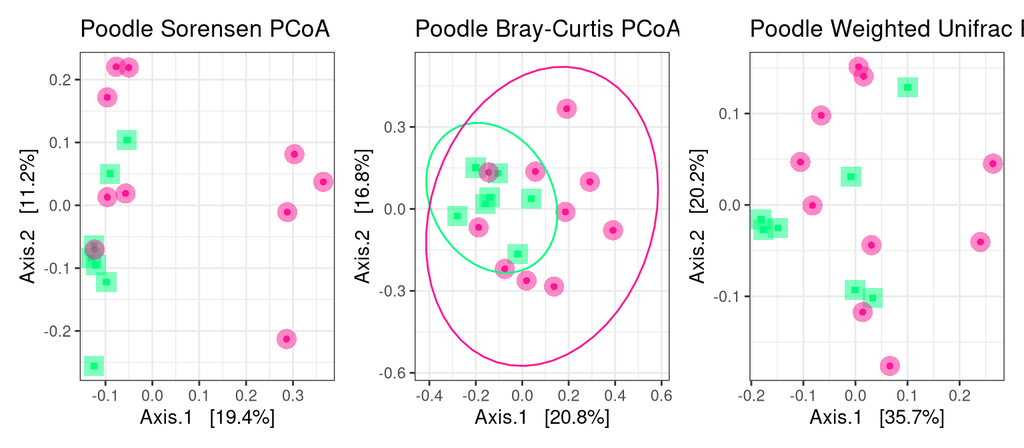

```r
(soren_poodle_pcoa + theme(legend.position = "none")) +
  (bray_poodle_pcoa + theme(legend.position = "none")) +
    (wUNI_poodle_pcoa + theme(legend.position = "none"))
```

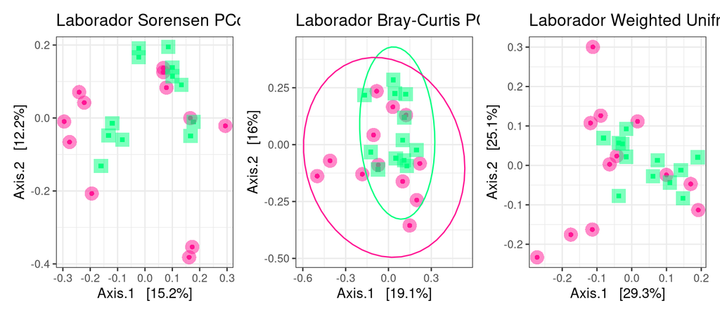

```r
(soren_laborador_pcoa + theme(legend.position = "none")) +
  (bray_laborador_pcoa + theme(legend.position = "none")) +
    (wUNI_laborador_pcoa + theme(legend.position = "none"))
```

## NMDS

### Weighted Unifrac

```r
# Calculate the Weighted Unifrac distance
scaled_wUNI_nmds <-
  ordinate(
    physeq = scaled_rooted_physeq,
    method = "NMDS",
    distance = "wunifrac")
```

```
## *** Best solution repeated 1 times
```

```r
health_scaled_wUNI_nmds <-
  ordinate(
    physeq = health_physeq,
    method = "NMDS",
    distance = "wunifrac")
```

```
## *** Best solution repeated 2 times
```

```r
poodle_scaled_wUNI_nmds <-
  ordinate(
    physeq = poodle_physeq,
    method = "NMDS",
    distance = "wunifrac")
```

```
## *** Best solution repeated 1 times
```

```r
laborador_scaled_wUNI_nmds <-
  ordinate(
    physeq = laborador_physeq,
    method = "NMDS",
    distance = "wunifrac")
```

```
## *** Best solution was not repeated -- monoMDS stopping criteria:
##     20: stress ratio > sratmax
```

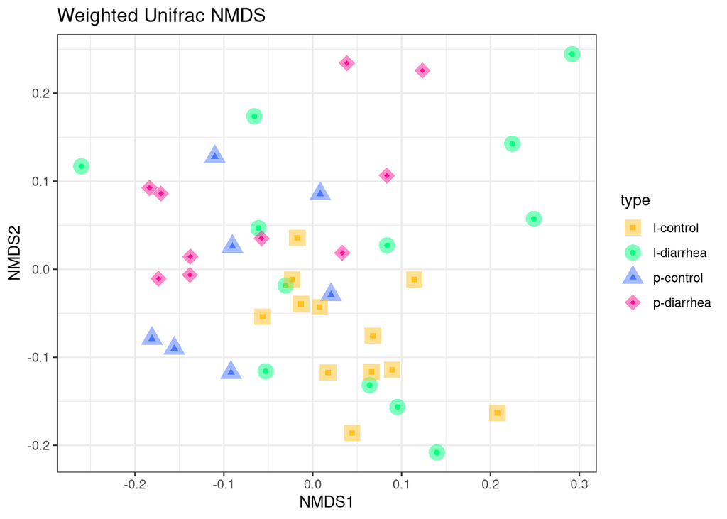

```r
# Plot the PCoA
wUNI_all_nmds <-
  plot_ordination(
    physeq = scaled_rooted_physeq,
    ordination = scaled_wUNI_nmds,
    color = "type",
    shape = "type",
    title = "Weighted Unifrac NMDS") +
  geom_point(size=5, alpha = 0.5, aes(color = type)) +
  scale_shape_manual(values = c(15,16,17,18, 19, 20)) +
  scale_color_manual(values = c(all_samples_colors)) +
  theme_bw()
wUNI_all_nmds
```

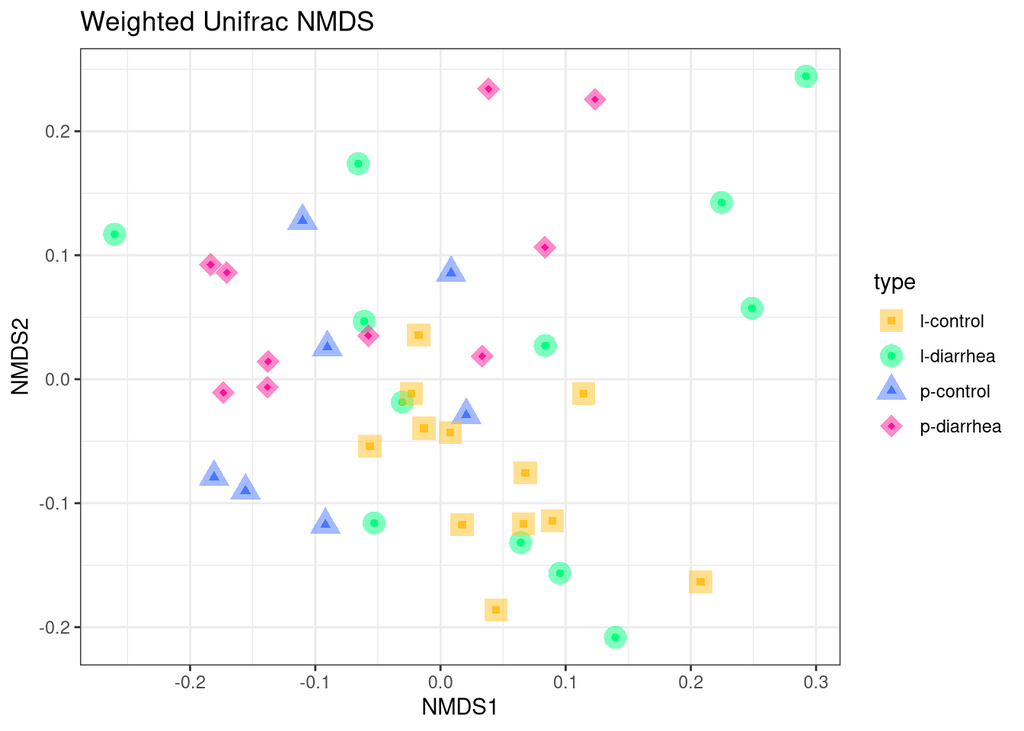

```r
wUNI_health_nmds <-
  plot_ordination(
    physeq = health_physeq,
    ordination = health_scaled_wUNI_nmds,
    color = "type",
    shape = "type",
    title = "Healthy Dogs Weighted Unifrac NMDS") +
  geom_point(size=5, alpha = 0.5, aes(color = type)) +
  scale_shape_manual(values = c(15,16,17,18, 19, 20)) +
  scale_color_manual(values = c(health_colors)) +
  theme_bw()
wUNI_all_nmds
```

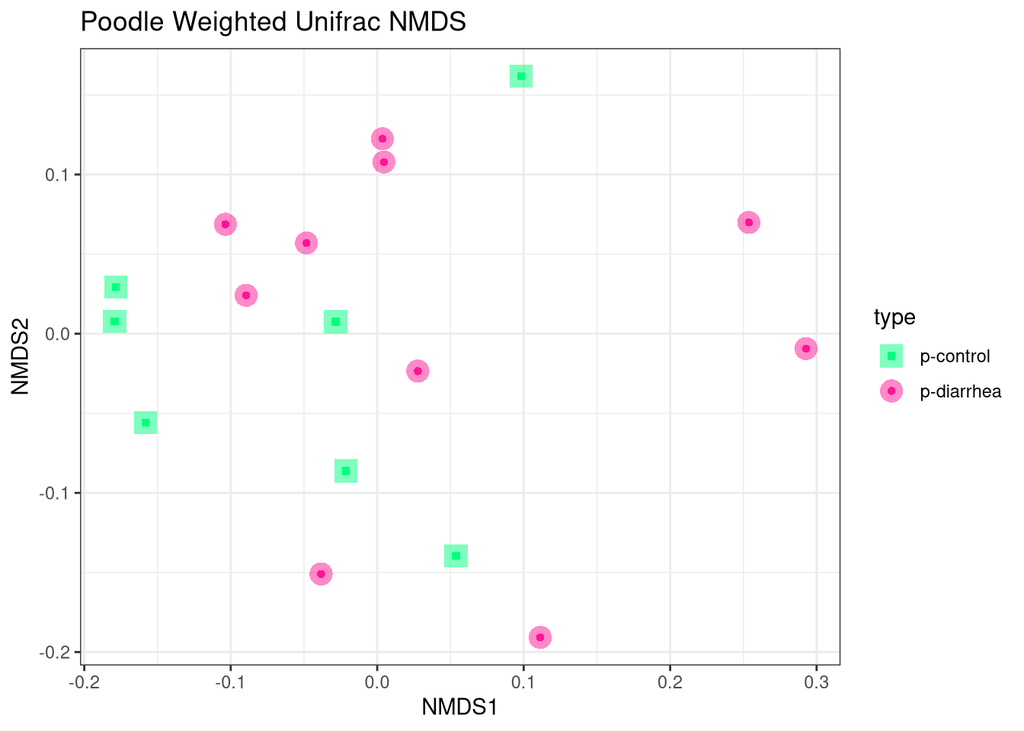

```r
wUNI_poodle_nmds <-
  plot_ordination(
    physeq = poodle_physeq,
    ordination = poodle_scaled_wUNI_nmds,
    color = "type",
    shape = "type",
    title = "Poodle Weighted Unifrac NMDS") +
  geom_point(size=5, alpha = 0.5, aes(color = type)) +
  scale_shape_manual(values = c(15,16,17,18, 19, 20)) +
  scale_color_manual(values = c(poodle_colors)) +
  theme_bw()
wUNI_poodle_nmds
```

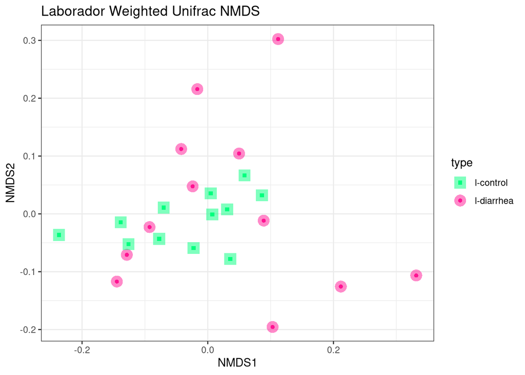

```r
wUNI_laborador_nmds <-
  plot_ordination(
    physeq = laborador_physeq,
    ordination = laborador_scaled_wUNI_nmds,
    color = "type",
    shape = "type",
    title = "Laborador Weighted Unifrac NMDS") +
  geom_point(size=5, alpha = 0.5, aes(color = type)) +
  scale_shape_manual(values = c(15,16,17,18, 19, 20)) +
  scale_color_manual(values = c(laborador_colors)) +
  theme_bw()
wUNI_laborador_nmds
```

The stress value is 0.18, 0.14, 0.13, 0.20 for all samples, samples from healthy dogs, samples from poodles, and samples from laboradors, respectively. All stress values are equal to or less than 0.20, which *may* be acceptable. Only two of the stress values (healthy samples and poodle samples) are less than 0.15.

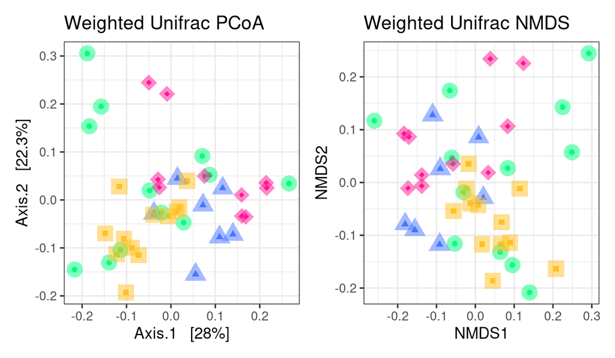

```r
(wUNI_all_pcoa + theme(legend.position = "none")) +
  (wUNI_all_nmds + theme(legend.position = "none"))
```

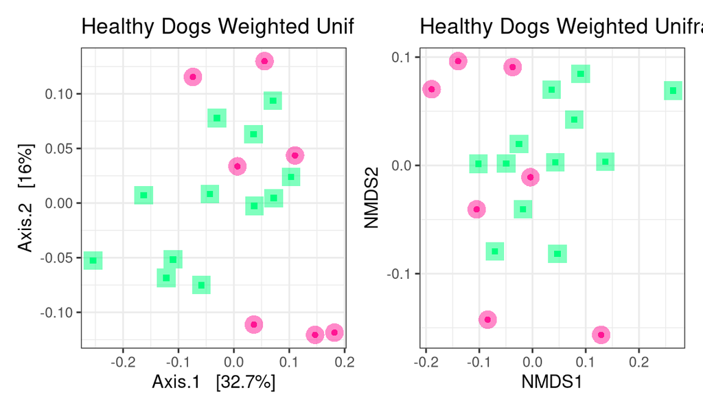

```r
(wUNI_health_pcoa + theme(legend.position = "none")) +
  (wUNI_health_nmds + theme(legend.position = "none"))
```

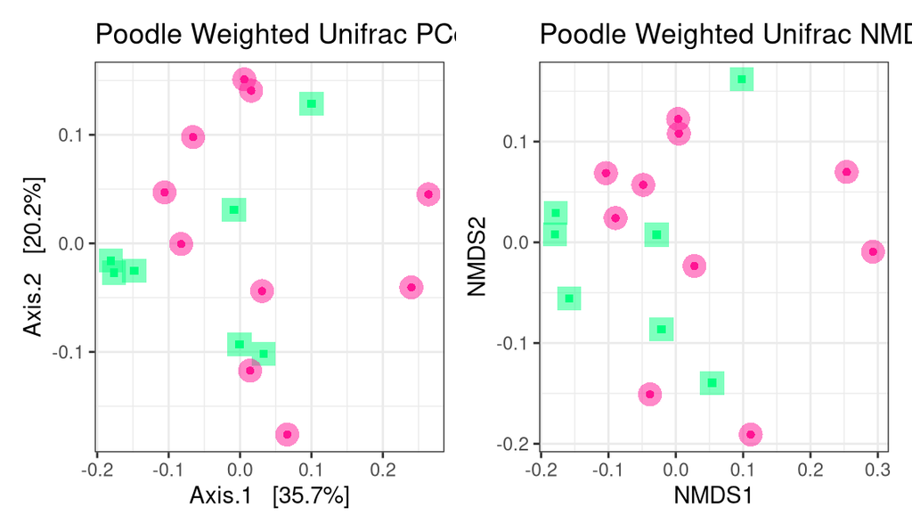

```r
(wUNI_poodle_pcoa + theme(legend.position = "none")) +
  (wUNI_poodle_nmds + theme(legend.position = "none"))
```

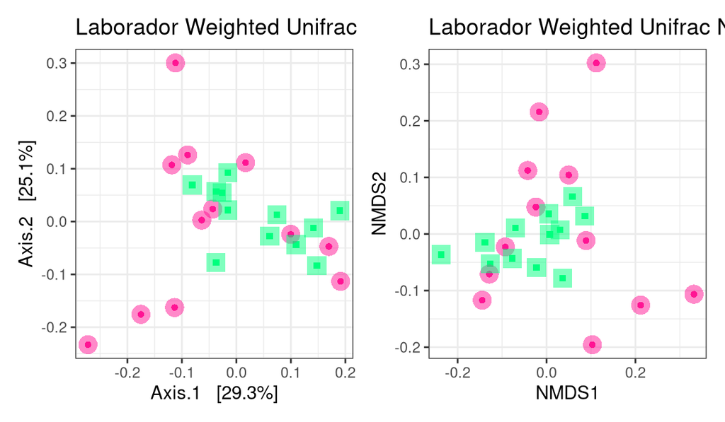

```r
(wUNI_laborador_pcoa + theme(legend.position = "none")) +
  (wUNI_laborador_nmds + theme(legend.position = "none"))
```

# Statistical Significance Testing

## PERMANOVA : all samples

```r
scaled_sorensen_dist <- phyloseq::distance(scaled_rooted_physeq, method = "bray", binary = TRUE)
scaled_bray_dist <- phyloseq::distance(scaled_rooted_physeq, method = "bray")
scaled_wUnifrac_dist <- phyloseq::distance(scaled_rooted_physeq, method = "wunifrac")

metadata <- data.frame(sample_data(scaled_rooted_physeq))

adonis2(scaled_sorensen_dist ~ type, data = metadata)
```

```
## Permutation test for adonis under reduced model
## Terms added sequentially (first to last)
## Permutation: free
## Number of permutations: 999
##
## adonis2(formula = scaled_sorensen_dist ~ type, data = metadata)
##          Df SumOfSqs      R2      F Pr(>F)
## type      3   0.8822 0.11823 1.6538  0.001 ***
## Residual 37   6.5789 0.88177
## Total    40   7.4611 1.00000
## ---
## Signif. codes:  0 '***' 0.001 '**' 0.01 '*' 0.05 '.' 0.1 ' ' 1
```

```r
adonis2(scaled_bray_dist ~ type, data = metadata)
```

```
## Permutation test for adonis under reduced model
## Terms added sequentially (first to last)
## Permutation: free
## Number of permutations: 999
##
## adonis2(formula = scaled_bray_dist ~ type, data = metadata)
##          Df SumOfSqs      R2      F Pr(>F)
## type      3   1.2197 0.16347 2.4101  0.001 ***
## Residual 37   6.2418 0.83653
## Total    40   7.4615 1.00000
## ---
## Signif. codes:  0 '***' 0.001 '**' 0.01 '*' 0.05 '.' 0.1 ' ' 1
```

```r
adonis2(scaled_wUnifrac_dist ~ type, data = metadata)
```

```
## Permutation test for adonis under reduced model
## Terms added sequentially (first to last)
## Permutation: free
## Number of permutations: 999
##
## adonis2(formula = scaled_wUnifrac_dist ~ type, data = metadata)
##          Df SumOfSqs      R2      F Pr(>F)
## type      3  0.34112 0.16316 2.4047  0.003 **
## Residual 37  1.74958 0.83684
## Total    40  2.09070 1.00000
## ---
## Signif. codes:  0 '***' 0.001 '**' 0.01 '*' 0.05 '.' 0.1 ' ' 1
```

**Interpretation**: The sample type is a significant variable for all of the beta diversity metrics. The Bray Curtis metric has the highest F-statistic (F = 2.41) for sample type. However, the Bray-Curtis and the weighted UniFrac have similar R2 values (~0.16), therefore these two metrics explain similar amounts of the data.

## PERMANOVA: healthy vs diarrhea dogs

```r
health_scaled_sorensen_dist <- phyloseq::distance(health_physeq, method = "bray", binary = TRUE)
health_scaled_bray_dist <- phyloseq::distance(health_physeq, method = "bray")
health_scaled_wUnifrac_dist <- phyloseq::distance(health_physeq, method = "wunifrac")

health_metadata <- data.frame(sample_data(health_physeq))

adonis2(health_scaled_sorensen_dist ~ type, data = health_metadata)
```

```
## Permutation test for adonis under reduced model
## Terms added sequentially (first to last)
## Permutation: free
## Number of permutations: 999
##
## adonis2(formula = health_scaled_sorensen_dist ~ type, data = health_metadata)
##          Df SumOfSqs      R2      F Pr(>F)
## type      1  0.29595 0.10452 1.9843  0.007 **
## Residual 17  2.53546 0.89548
## Total    18  2.83141 1.00000
## ---
## Signif. codes:  0 '***' 0.001 '**' 0.01 '*' 0.05 '.' 0.1 ' ' 1
```

```r
adonis2(health_scaled_bray_dist ~ type, data = health_metadata)
```

```
## Permutation test for adonis under reduced model
## Terms added sequentially (first to last)
## Permutation: free
## Number of permutations: 999
##
## adonis2(formula = health_scaled_bray_dist ~ type, data = health_metadata)
##          Df SumOfSqs      R2      F Pr(>F)
## type      1  0.23531 0.08871 1.6549   0.04 *
## Residual 17  2.41721 0.91129
## Total    18  2.65252 1.00000
## ---
## Signif. codes:  0 '***' 0.001 '**' 0.01 '*' 0.05 '.' 0.1 ' ' 1
```

```r
adonis2(health_scaled_wUnifrac_dist ~ type, data = health_metadata)
```

```
## Permutation test for adonis under reduced model
## Terms added sequentially (first to last)
## Permutation: free
## Number of permutations: 999
##
## adonis2(formula = health_scaled_wUnifrac_dist ~ type, data = health_metadata)
##          Df SumOfSqs      R2      F Pr(>F)
## type      1  0.08808 0.12841 2.5046   0.02 *
## Residual 17  0.59787 0.87159
## Total    18  0.68596 1.00000
## ---
## Signif. codes:  0 '***' 0.001 '**' 0.01 '*' 0.05 '.' 0.1 ' ' 1
```

**Interpretation:** The “type” variable has a p-value is less than 0.05 for all diversity metrics. This means that the healthy and control sample types have significantly different centroids. The weighted Unifrac has the highest R2 value (explains the most difference) and the highest F-statistic (F = 2.5) for the sample type variable.

## PERMANOVA: poodles

```r
# Calculate all three of the distance matrices
poodle_scaled_sorensen_dist <- phyloseq::distance(poodle_physeq, method = "bray", binary = TRUE)
poodle_scaled_bray_dist <- phyloseq::distance(poodle_physeq, method = "bray")
poodle_scaled_wUnifrac_dist <- phyloseq::distance(poodle_physeq, method = "wunifrac")

poodle_metadata <- data.frame(sample_data(poodle_physeq))

adonis2(poodle_scaled_sorensen_dist ~ type, data = poodle_metadata)
```

```
## Permutation test for adonis under reduced model
## Terms added sequentially (first to last)
## Permutation: free
## Number of permutations: 999
##
## adonis2(formula = poodle_scaled_sorensen_dist ~ type, data = poodle_metadata)
##          Df SumOfSqs      R2      F Pr(>F)
## type      1  0.26642 0.09974 1.6618  0.021 *
## Residual 15  2.40486 0.90026
## Total    16  2.67128 1.00000
## ---
## Signif. codes:  0 '***' 0.001 '**' 0.01 '*' 0.05 '.' 0.1 ' ' 1
```

```r
adonis2(poodle_scaled_bray_dist ~ type, data = poodle_metadata)
```

```
## Permutation test for adonis under reduced model
## Terms added sequentially (first to last)
## Permutation: free
## Number of permutations: 999
##
## adonis2(formula = poodle_scaled_bray_dist ~ type, data = poodle_metadata)
##          Df SumOfSqs      R2      F Pr(>F)
## type      1  0.26751 0.09789 1.6276  0.046 *
## Residual 15  2.46537 0.90211
## Total    16  2.73288 1.00000
## ---
## Signif. codes:  0 '***' 0.001 '**' 0.01 '*' 0.05 '.' 0.1 ' ' 1
```

```r
adonis2(poodle_scaled_wUnifrac_dist ~ type, data = poodle_metadata)
```

```
## Permutation test for adonis under reduced model
## Terms added sequentially (first to last)
## Permutation: free
## Number of permutations: 999
##
## adonis2(formula = poodle_scaled_wUnifrac_dist ~ type, data = poodle_metadata)
##          Df SumOfSqs      R2      F Pr(>F)
## type      1  0.06564 0.09271 1.5328  0.159
## Residual 15  0.64238 0.90729
## Total    16  0.70802 1.00000
```

## PERMANOVA: laboradors

```r
# Calculate all three of the distance matrices
laborador_scaled_sorensen_dist <- phyloseq::distance(laborador_physeq, method = "bray", binary = TRUE)
laborador_scaled_bray_dist <- phyloseq::distance(laborador_physeq, method = "bray")
laborador_scaled_wUnifrac_dist <- phyloseq::distance(laborador_physeq, method = "wunifrac")


laborador_metadata <- data.frame(sample_data(laborador_physeq))


adonis2(laborador_scaled_sorensen_dist ~ type, data = laborador_metadata)
```

```
## Permutation test for adonis under reduced model
## Terms added sequentially (first to last)
## Permutation: free
## Number of permutations: 999
##
## adonis2(formula = laborador_scaled_sorensen_dist ~ type, data = laborador_metadata)
##          Df SumOfSqs      R2      F Pr(>F)
## type      1   0.1990 0.04552 1.0491  0.342
## Residual 22   4.1740 0.95448
## Total    23   4.3731 1.00000
```

```r
adonis2(laborador_scaled_bray_dist ~ type, data = laborador_metadata)
```

```
## Permutation test for adonis under reduced model
## Terms added sequentially (first to last)
## Permutation: free
## Number of permutations: 999
##
## adonis2(formula = laborador_scaled_bray_dist ~ type, data = laborador_metadata)
##          Df SumOfSqs      R2      F Pr(>F)
## type      1   0.2428 0.06041 1.4145  0.102
## Residual 22   3.7764 0.93959
## Total    23   4.0193 1.00000
```

```r
adonis2(laborador_scaled_wUnifrac_dist ~ type, data = laborador_metadata)
```

```
## Permutation test for adonis under reduced model
## Terms added sequentially (first to last)
## Permutation: free
## Number of permutations: 999
##
## adonis2(formula = laborador_scaled_wUnifrac_dist ~ type, data = laborador_metadata)
##          Df SumOfSqs      R2      F Pr(>F)
## type      1  0.06408 0.05471 1.2733  0.249
## Residual 22  1.10721 0.94529
## Total    23  1.17129 1.00000
```

**Interpretation**: For the Labrador samples, none of the beta diversity metrics indicate sample type (control vs diarrhea) as having signficant differences in the centroid of the data. Additionally, all of the R2 values are less than 10% and the all F-statistics for sample type are less than 1.5.

## BetaDispR

The PERMANOVA is sensitive to variance/dispersion in the data. Therefore, we need to run a homogeneity of dispersion test to test for the sensitivity of our PERMANOVA results to variance.

```r
# Homogeneity of Disperson test with beta dispr
# Sorensen
beta_soren_all <- betadisper(scaled_sorensen_dist, metadata$type)
permutest(beta_soren_all)
```

```
##
## Permutation test for homogeneity of multivariate dispersions
## Permutation: free
## Number of permutations: 999
##
## Response: Distances
##           Df   Sum Sq   Mean Sq      F N.Perm Pr(>F)
## Groups     3 0.062438 0.0208127 5.1577    999  0.006 **
## Residuals 37 0.149305 0.0040353
## ---
## Signif. codes:  0 '***' 0.001 '**' 0.01 '*' 0.05 '.' 0.1 ' ' 1
```

```r
beta_soren_health <- betadisper(health_scaled_sorensen_dist, health_metadata$type)
permutest(beta_soren_health)
```

```
##
## Permutation test for homogeneity of multivariate dispersions
## Permutation: free
## Number of permutations: 999
##
## Response: Distances
##           Df   Sum Sq   Mean Sq      F N.Perm Pr(>F)
## Groups     1 0.013273 0.0132727 4.0177    999   0.05 *
## Residuals 17 0.056161 0.0033036
## ---
## Signif. codes:  0 '***' 0.001 '**' 0.01 '*' 0.05 '.' 0.1 ' ' 1
```

```r
beta_soren_poodle <- betadisper(poodle_scaled_sorensen_dist, poodle_metadata$type)
permutest(beta_soren_poodle)
```

```
##
## Permutation test for homogeneity of multivariate dispersions
## Permutation: free
## Number of permutations: 999
##
## Response: Distances
##           Df   Sum Sq   Mean Sq      F N.Perm Pr(>F)
## Groups     1 0.024192 0.0241917 7.8311    999  0.015 *
## Residuals 15 0.046338 0.0030892
## ---
## Signif. codes:  0 '***' 0.001 '**' 0.01 '*' 0.05 '.' 0.1 ' ' 1
```

```r
beta_soren_laborador <- betadisper(laborador_scaled_sorensen_dist, laborador_metadata$type)
permutest(beta_soren_laborador)
```

```
##
## Permutation test for homogeneity of multivariate dispersions
## Permutation: free
## Number of permutations: 999
##
## Response: Distances
##           Df  Sum Sq   Mean Sq      F N.Perm Pr(>F)
## Groups     1 0.02222 0.0222197 4.7472    999  0.043 *
## Residuals 22 0.10297 0.0046806
## ---
## Signif. codes:  0 '***' 0.001 '**' 0.01 '*' 0.05 '.' 0.1 ' ' 1
```

```r
# Bray-Curtis
beta_bray_all <- betadisper(scaled_bray_dist, metadata$type)
permutest(beta_bray_all)
```

```
##
## Permutation test for homogeneity of multivariate dispersions
## Permutation: free
## Number of permutations: 999
##
## Response: Distances
##           Df   Sum Sq   Mean Sq     F N.Perm Pr(>F)
## Groups     3 0.038037 0.0126791 2.127    999  0.127
## Residuals 37 0.220562 0.0059611
```

```r
beta_bray_health <- betadisper(health_scaled_bray_dist, health_metadata$type)
permutest(beta_bray_health)
```

```
##
## Permutation test for homogeneity of multivariate dispersions
## Permutation: free
## Number of permutations: 999
##
## Response: Distances
##           Df   Sum Sq   Mean Sq      F N.Perm Pr(>F)
## Groups     1 0.000012 0.0000116 0.0035    999  0.949
## Residuals 17 0.056640 0.0033318
```

```r
beta_bray_poodle <- betadisper(poodle_scaled_bray_dist, poodle_metadata$type)
permutest(beta_bray_poodle)
```

```
##
## Permutation test for homogeneity of multivariate dispersions
## Permutation: free
## Number of permutations: 999
##
## Response: Distances
##           Df   Sum Sq   Mean Sq      F N.Perm Pr(>F)
## Groups     1 0.005428 0.0054276 0.9959    999  0.329
## Residuals 15 0.081748 0.0054498
```

```r
beta_bray_laborador <- betadisper(laborador_scaled_bray_dist, laborador_metadata$type)
permutest(beta_bray_laborador)
```

```
##
## Permutation test for homogeneity of multivariate dispersions
## Permutation: free
## Number of permutations: 999
##
## Response: Distances
##           Df   Sum Sq   Mean Sq      F N.Perm Pr(>F)
## Groups     1 0.030969 0.0309689 4.8511    999  0.037 *
## Residuals 22 0.140447 0.0063839
## ---
## Signif. codes:  0 '***' 0.001 '**' 0.01 '*' 0.05 '.' 0.1 ' ' 1
```

**Interpretation:** The sample type variable is not signficantly impacted by dispersion for the all samples BC, the healthy dogs BC, and the poodles BC. However, sample type is sensitive to dispersion for the laborador BC.

```r
# Weighted Unifrac
beta_wUNi_all <- betadisper(scaled_wUnifrac_dist, metadata$type)
permutest(beta_wUNi_all)
```

```
##
## Permutation test for homogeneity of multivariate dispersions
## Permutation: free
## Number of permutations: 999
##
## Response: Distances
##           Df   Sum Sq   Mean Sq      F N.Perm Pr(>F)
## Groups     3 0.036611 0.0122035 3.3497    999  0.023 *
## Residuals 37 0.134799 0.0036432
## ---
## Signif. codes:  0 '***' 0.001 '**' 0.01 '*' 0.05 '.' 0.1 ' ' 1
```

```r
beta_wUNi_health <- betadisper(health_scaled_wUnifrac_dist, health_metadata$type)
permutest(beta_wUNi_health)
```

```
##
## Permutation test for homogeneity of multivariate dispersions
## Permutation: free
## Number of permutations: 999
##
## Response: Distances
##           Df   Sum Sq    Mean Sq      F N.Perm Pr(>F)
## Groups     1 0.000587 0.00058704 0.2461    999  0.648
## Residuals 17 0.040554 0.00238551
```

```r
beta_wUNi_poodle <- betadisper(poodle_scaled_wUnifrac_dist, poodle_metadata$type)
permutest(beta_wUNi_poodle)
```

```
##
## Permutation test for homogeneity of multivariate dispersions
## Permutation: free
## Number of permutations: 999
##
## Response: Distances
##           Df   Sum Sq   Mean Sq      F N.Perm Pr(>F)
## Groups     1 0.000773 0.0007726 0.1992    999  0.667
## Residuals 15 0.058167 0.0038778
```

```r
beta_wUNi_laborador <- betadisper(laborador_scaled_wUnifrac_dist, laborador_metadata$type)
permutest(beta_wUNi_laborador)
```

```
##
## Permutation test for homogeneity of multivariate dispersions
## Permutation: free
## Number of permutations: 999
##
## Response: Distances
##           Df   Sum Sq  Mean Sq      F N.Perm Pr(>F)
## Groups     1 0.032791 0.032791 9.3172    999  0.003 **
## Residuals 22 0.077428 0.003519
## ---
## Signif. codes:  0 '***' 0.001 '**' 0.01 '*' 0.05 '.' 0.1 ' ' 1
```

# Taxonomic

```r
# Set the phylum colors
phylum_colors <- c(
  Acidobacteriota = "navy",
  Actinobacteriota = "darkslategray2",
  Armatimonadota = "deeppink1",
  Alphaproteobacteria = "plum2",
  Bacteroidota = "gold",
  Betaproteobacteria = "plum1",
  Bdellovibrionota = "red1",
  Chloroflexi="black",
  Crenarchaeota = "firebrick",
  Cyanobacteria = "limegreen",
  Deltaproteobacteria = "grey",
  Desulfobacterota="magenta",
  Firmicutes = "#3E9B96",
  Gammaproteobacteria = "greenyellow",
  Myxococcota = "#B5D6AA",
  Nitrospirota = "palevioletred1",
  Proteobacteria = "royalblue",
  Planctomycetota = "darkorange",
  Proteobacteria_unclassified = "greenyellow",
  Thermoplasmatota = "green",
  Verrucomicrobiota = "darkorchid1",
  Other = "grey")
```

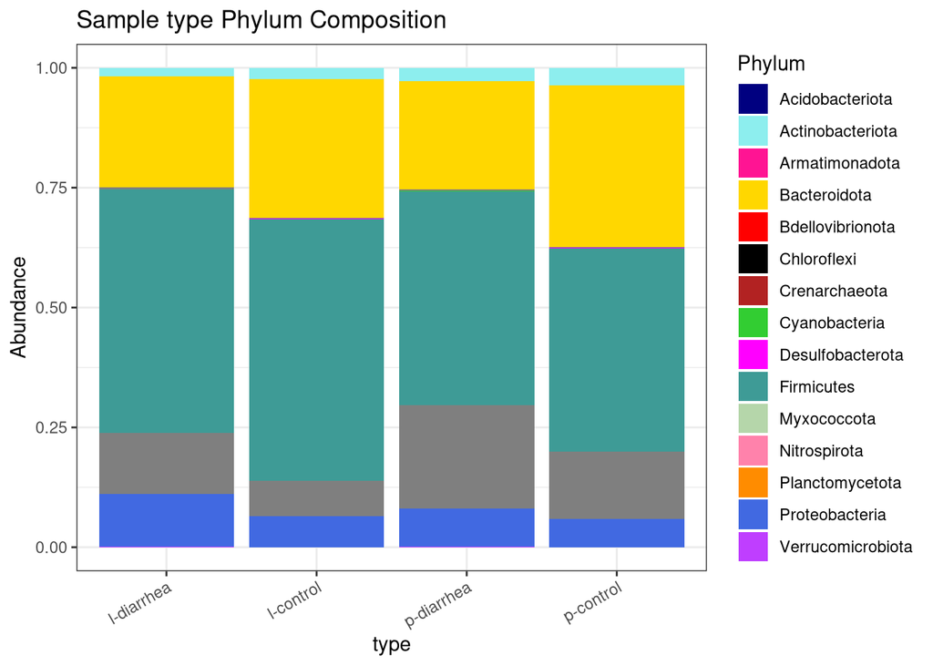

```r
# Calculate the phylum relative abundance
# Note: The read depth MUST be normalized in some way: scale_reads
phylum_df <-
  scaled_rooted_physeq %>%
  # agglomerate at the phylum level
  tax_glom(taxrank = "Phylum") %>%
  # Transform counts to relative abundance
  transform_sample_counts(function (x) {x/sum(x)}) %>%
  # Melt to a long format
  psmelt() %>%
  # Filter out Phyla that are <1% - get rid of low abundant Phyla
  dplyr::filter(Abundance > 0.00) %>%
  # fix the order of date
  mutate(type = fct_relevel(type, c("l-diarrhea", "l-control",
                                          "p-diarrhea", "p-control")))

# Stacked Bar Plot With All phyla
# Plot Phylum Abundances - make sure to load phylum_colors
phylum_df %>%
  # Warning: It's important to have one sample per x value,
  # otherwise, it will take the sum between multiple samples
  ggplot(aes(x = type, y = Abundance, fill = Phylum)) +
  geom_bar(stat = "identity", position = "fill") +
  labs(title = "Sample type Phylum Composition") +
  scale_fill_manual(values = phylum_colors) +
  theme_bw() +
  theme(axis.text.x = element_text(angle = 30, hjust = 1, vjust = 1))
```

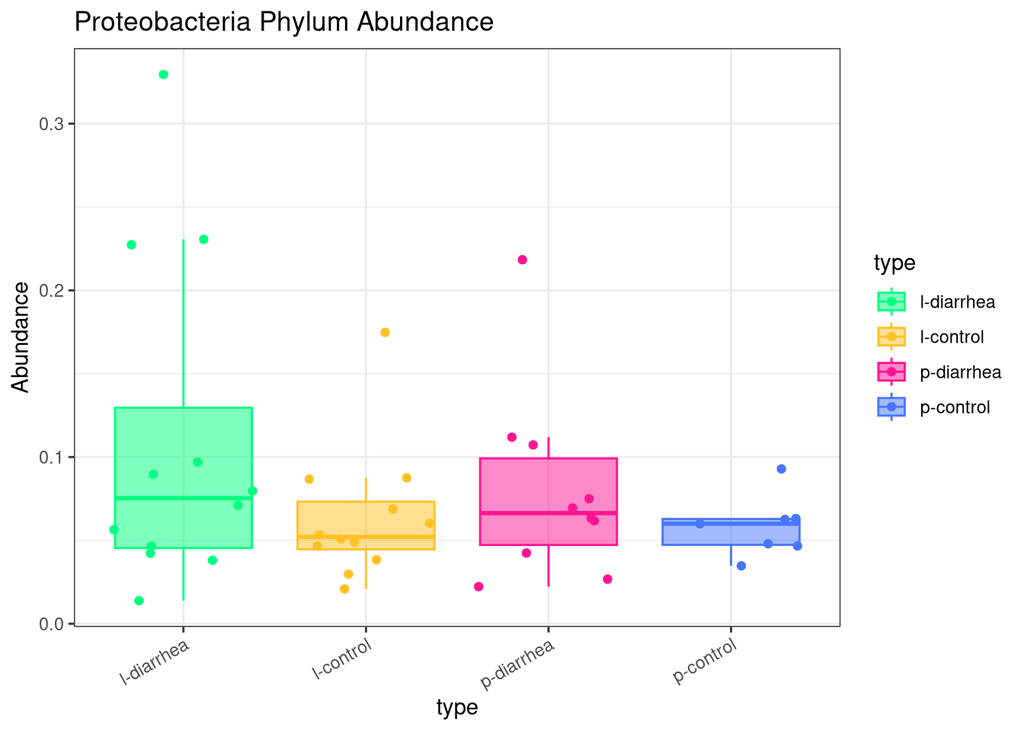

```r
# Narrow in on a specific group
phylum_df %>%
  dplyr::filter(Phylum == "Proteobacteria") %>%
  # build the plot
  ggplot(aes(x = type, y = Abundance,
             fill = type, color = type)) +
  geom_boxplot(alpha = 0.5, outlier.shape = NA) + # outliers not plotted here in boxplot
  geom_jitter() +
  theme_bw() +
  labs(title = "Proteobacteria Phylum Abundance") +
  scale_color_manual(values = all_samples_colors) +
  scale_fill_manual(values = all_samples_colors) +
    theme(axis.text.x = element_text(angle = 30, hjust = 1, vjust = 1),
          legend.position = "right")
```

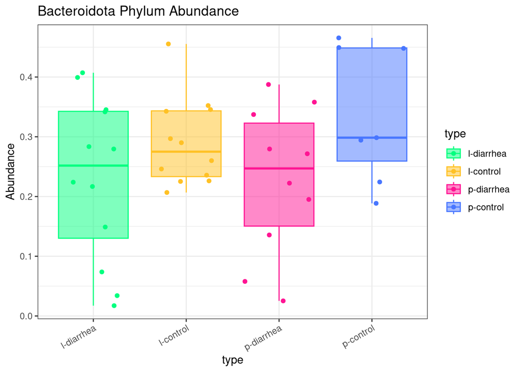

```r
phylum_df %>%
  dplyr::filter(Phylum == "Bacteroidota") %>%
  # build the plot
  ggplot(aes(x = type, y = Abundance,
             fill = type, color = type)) +
  geom_boxplot(alpha = 0.5, outlier.shape = NA) + # outliers not plotted here in boxplot
  geom_jitter() +
  theme_bw() +
  labs(title = "Bacteroidota Phylum Abundance") +
  scale_color_manual(values = all_samples_colors) +
  scale_fill_manual(values = all_samples_colors) +
    theme(axis.text.x = element_text(angle = 30, hjust = 1, vjust = 1),
          legend.position = "right")
```

# Family

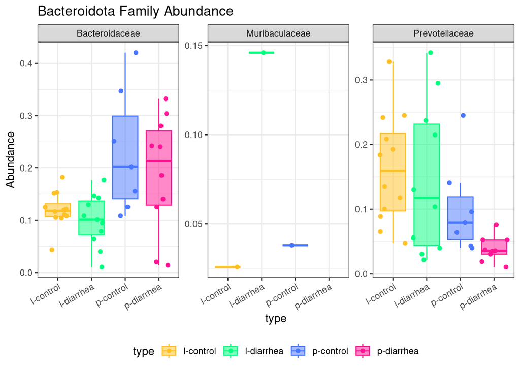

```r
# Calculate the Family relative abundance
# Note: The read depth MUST be normalized in some way: scale_reads
family_df <-
  scaled_rooted_physeq %>%
  # agglomerate at the phylum level
  tax_glom(taxrank = "Family") %>%
  # Transform counts to relative abundance
  transform_sample_counts(function (x) {x/sum(x)}) %>%
  # Melt to a long format
  psmelt() %>%
  # Filter out Phyla that are <1% - get rid of low abundant Phyla
  dplyr::filter(Abundance > 0.01)

# Check family_df
#str(family_df)

# Plot family
# Bacteroidota Families
family_df %>%
  dplyr::filter(Phylum == "Bacteroidota") %>%
  # build the plot
  ggplot(aes(x = type, y = Abundance,
             fill = type, color = type)) +
  facet_wrap(.~Family, scales = "free_y", nrow = 1) +
  geom_boxplot(alpha = 0.5, outlier.shape = NA) + # outliers not plotted here in boxplot
  geom_jitter() +
  theme_bw() +
  labs(title = "Bacteroidota Family Abundance") +
  scale_color_manual(values = all_samples_colors) +
  scale_fill_manual(values = all_samples_colors) +
  theme(axis.text.x = element_text(angle = 30, hjust = 1, vjust = 1),
        legend.position = "bottom")
```

# Genus

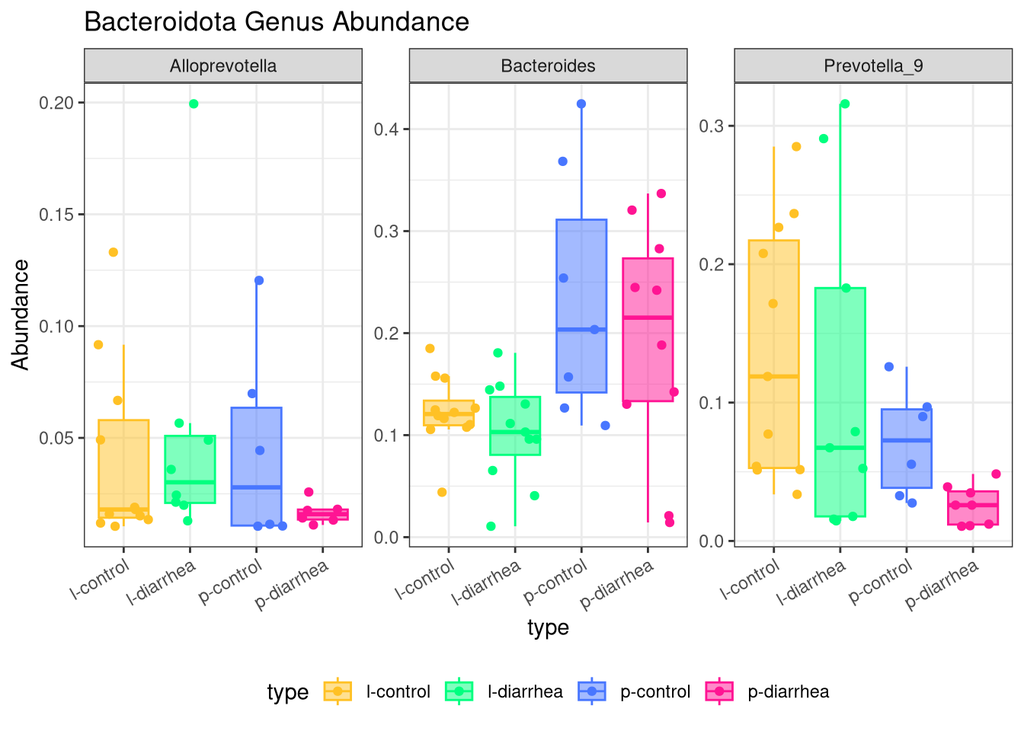

```r
#Calculate the Family relative abundance
# Note: The read depth MUST be normalized in some way: scale_reads
genus_df <-
  scaled_rooted_physeq %>%
  # agglomerate at the phylum level
  tax_glom(taxrank = "Genus") %>%
  # Transform counts to relative abundance
  transform_sample_counts(function (x) {x/sum(x)}) %>%
  # Melt to a long format
  psmelt() %>%
  # Filter out Phyla that are <1% - get rid of low abundant Phyla
  dplyr::filter(Abundance > 0.01)

# Bacteroidota
# Plot genus
genus_df %>%
  dplyr::filter(Phylum == "Bacteroidota") %>%
  # build the plot
  ggplot(aes(x = type, y = Abundance,
             fill = type, color = type)) +
  facet_wrap(.~Genus, scales = "free_y", nrow = 1) +
  geom_boxplot(alpha = 0.5, outlier.shape = NA) + # outliers not plotted here in boxplot
  geom_jitter() +
  theme_bw() +
  labs(title = "Bacteroidota Genus Abundance") +
  scale_color_manual(values = all_samples_colors) +
  scale_fill_manual(values = all_samples_colors) +
  theme(axis.text.x = element_text(angle = 30, hjust = 1, vjust = 1),
        legend.position = "bottom")
```